# Reproducible Research: Peer Assessment 1

## Introduction

It is now possible to collect a large amount of data about personal movement using activity monitoring devices such as a Fitbit, Nike Fuelband, or Jawbone Up. These type of devices are part of the “quantified self” movement - a group of enthusiasts who take measurements about themselves regularly to improve their health, to find patterns in their behavior, or because they are tech geeks. But these data remain under-utilized both because the raw data are hard to obtain and there is a lack of statistical methods and software for processing and interpreting the data.

This assignment makes use of data from a personal activity monitoring device. This device collects data at 5 minute intervals through out the day. The data consists of two months of data from an anonymous individual collected during the months of October and November, 2012 and include the number of steps taken in 5 minute intervals each day.

## Loading and preprocessing the data

In this section, we are going to load the supplied data set into a base data frame named activity_df. This data frame will be used for aggregation through out this exercise.

```r
unzip("./activity.zip")
activity_df <- read.csv("activity.csv")
```

## What is mean total number of steps taken per day?

In order to answer this question, the data set needs to be grouped by date. This is illustrated below:

```r
day_df <- group_by(activity_df,date)
```

Once we have applied the grouping, we can create a data frame with the summarized data on sum of steps taken per day:

```r
total_day <- summarise(day_df, sum_steps=sum(steps))

# Let's check how our data looks like:

total_day
```

```
## Source: local data frame [61 x 2]
##
##          date sum_steps
## 1  2012-10-01        NA
## 2  2012-10-02       126
## 3  2012-10-03     11352
## 4  2012-10-04     12116
## 5  2012-10-05     13294
## 6  2012-10-06     15420
## 7  2012-10-07     11015
## 8  2012-10-08        NA
## 9  2012-10-09     12811
## 10 2012-10-10      9900
## ..        ...       ...
```

Following code will plot out a histogram on the total number of steps taken each day

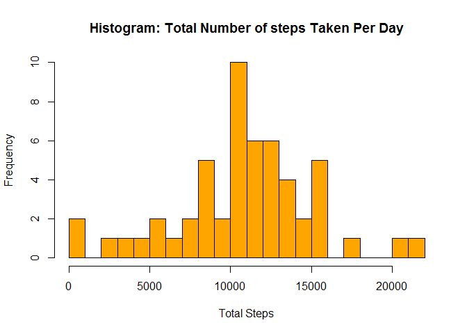

```r
hist(total_day$sum_steps, col="orange", breaks=20, main="Histogram: Total Number of steps Taken Per Day", xlab="Total Steps", ylab="Frequency")
```

After all, this doesn’t really help us to answer the question. If you may recall, we are trying to find out the **mean** total number of steps taken per day. Let’s add a mean line to the histogram:

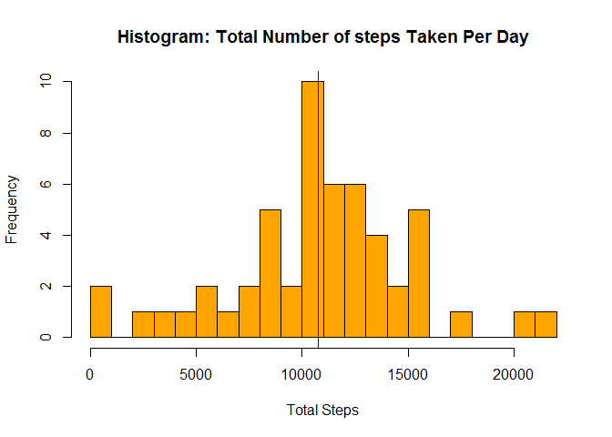

```r
mean1 <- mean(total_day$sum_steps, na.rm=TRUE)

hist(total_day$sum_steps, col="orange", breaks=20, main="Histogram: Total Number of steps Taken Per Day", xlab="Total Steps", ylab="Frequency")
abline(v = mean1, col = "blue", lwd = 1)
```

Here’s the calculation of **mean and median of the total number of steps taken per day**:

```r
mean(total_day$sum_steps, na.rm=TRUE)
```

```
## [1] 10766.19
```

```r
median(total_day$sum_steps, na.rm=TRUE)
```

```
## [1] 10765
```

## What is the average daily activity pattern?

We can plot a time series line chart to illustrate the average daily activity pattern. Before the chart can be plotted, the data has to be aggregated based on the “interval”:

```r
interval_df <- group_by(activity_df,interval)
```

```r
mean_interval <- summarise(interval_df, mean_steps=mean(steps,na.rm=TRUE))

# Let's check how our data looks like:

mean_interval
```

```
## Source: local data frame [288 x 2]
##
##    interval mean_steps
## 1         0  1.7169811
## 2         5  0.3396226
## 3        10  0.1320755
## 4        15  0.1509434
## 5        20  0.0754717
## 6        25  2.0943396
## 7        30  0.5283019
## 8        35  0.8679245
## 9        40  0.0000000
## 10       45  1.4716981
## ..      ...        ...
```

Following code snippet produces the time series line chart of average number of steps taken across all day:

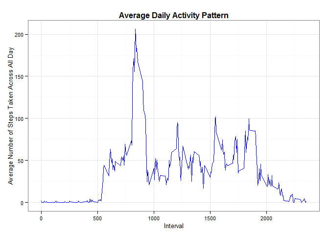

```r
g2 <- ggplot(mean_interval, aes(interval,mean_steps))
plot2 <- g2 + geom_line(colour="blue") + theme_bw(base_size = 10) + labs(x = "Interval") + labs(y = "Average Number of Steps Taken Across All Day") + ggtitle("Average Daily Activity Pattern") + theme(plot.title = element_text(lineheight=.8, face="bold"))
plot2
```

Fllowing calculation shows which 5-minute interval contains the maximum number of avarage steps:

```r
mean_interval[mean_interval$mean_steps==max(mean_interval$mean_steps),]
```

```
## Source: local data frame [1 x 2]
##
##   interval mean_steps
## 1      835   206.1698
```

## Imputing missing values

There are a number of days/intervals where there are missing **steps** value. The presence of missing value may introduce bias into some calculations or summaries of the data.

It is not uncommon to patch the data with some defined value derived from data set. The completeness of data (with the patched data) provides us a better picture of the data summmary.

First, let’s find out the rows of data that needs to be patched (with steps value of NA):

```r
# Construct a data frame which consist of all activity that has NA value in it:

na_activity <- activity_df[is.na(activity_df$steps),]

head(na_activity,10)
```

```
##    steps       date interval
## 1     NA 2012-10-01        0
## 2     NA 2012-10-01        5
## 3     NA 2012-10-01       10
## 4     NA 2012-10-01       15
## 5     NA 2012-10-01       20
## 6     NA 2012-10-01       25
## 7     NA 2012-10-01       30
## 8     NA 2012-10-01       35
## 9     NA 2012-10-01       40
## 10    NA 2012-10-01       45
```

Following shows the number of rows that needs to be patched:

```r
# number of records that needs to be patched:

nrow(na_activity)
```

```
## [1] 2304
```

It shows that 2304 rows of data needs to be patched. We will use the average value of steps for specific interval to fill in the gap here. This piece of information is already available in our previous derived data frame named *mean_interval*.

We will use the mean_steps value available in *mean_interval* to patch the data.

```r
tmp_merge <- merge(mean_interval,na_activity, by.x="interval", by.y="interval")
merge_df <- select(tmp_merge, mean_steps, date, interval)
colnames(merge_df)[1] <- "steps"
```

Let’s also derived a data set that has **steps** value not equal to NA:

```r
non_na_activity <- activity_df[!is.na(activity_df$steps),]
```

The patched data set will be merged with this newly derived data frame, this yield us a new data frame that has all the missing value filled up

```r
complete_df <- rbind(non_na_activity, merge_df)
```

Sort it based on date and interval:

```r
complete_df <- sqldf('select * from complete_df order by date, interval;')
```

We will now make a new histogram to show the the total number of steps taken each day

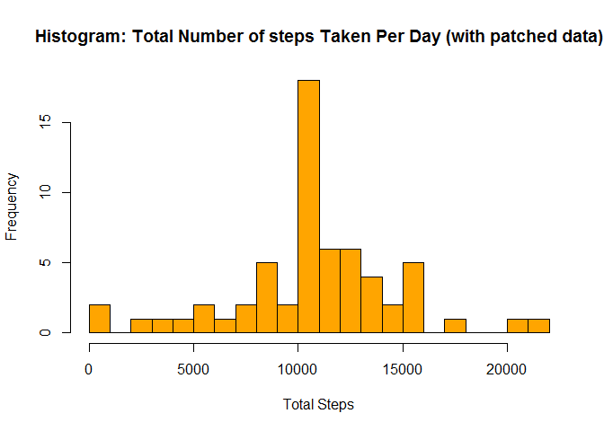

```r
day_df <- group_by(complete_df,date)
total_day <- summarise(day_df, sum_steps=sum(steps))
hist(total_day$sum_steps, col="orange", breaks=20, main="Histogram: Total Number of steps Taken Per Day (with patched data)", xlab="Total Steps", ylab="Frequency")
```

Here’s the calculation of **mean and median of the total number of steps taken per day** after tha missing value has been patched:

```r
mean(total_day$sum_steps, na.rm=TRUE)
```

```
## [1] 10766.19
```

```r
median(total_day$sum_steps, na.rm=TRUE)
```

```
## [1] 10766.19
```

These values has not much difference with the values in first part of the assignment. This is due to the data used to patch the NA value is derived from every 5 minutes interval mean.

Although the difference is small, we can see the median is now equal to mean. This means the current data set is more symmetrical than the previous one.

## Are there differences in activity patterns between weekdays and weekends?

In order to compare the activity patterns, we need to add a column in our patched data set to indicate if the date data is a weekday or weekend:

```r
week_day <- weekdays(as.Date(complete_df$date))
week_day <- ifelse(week_day %in% c("Monday","Tuesday","Wednesday","Thursday", "Friday"), "weekday", "weekend")
complete_df <- cbind(complete_df, week_day)
```

Group the data by interval and find out the mean per interval:

```r
interval_df <- group_by(complete_df,interval, week_day)
mean_interval <- summarise(interval_df, mean_steps=mean(steps,na.rm=TRUE))
```

Following code snippet produces the time series line chart of average number of steps taken across all day divided by weekday and weekend facet:

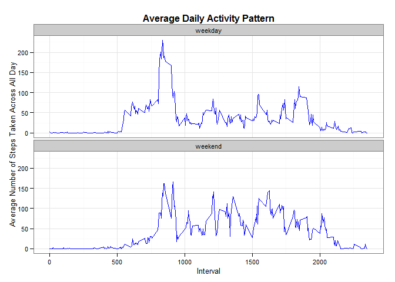

```r
g4 <- ggplot(mean_interval, aes(interval,mean_steps))
plot4 <- g4 + geom_line(colour="blue") + theme_bw(base_size = 10) + labs(x = "Interval") + labs(y = "Average Number of Steps Taken Across All Day") + ggtitle("Average Daily Activity Pattern") + theme(plot.title = element_text(lineheight=.8, face="bold")) + facet_wrap(~week_day, nrow=2)
plot4
```